# 绘制中国地图

Snake

2016年1月29日

自从用了ggplot2包，越来越觉得其博大精深，通过图层的概念可以绘制丰富的可视化图形，如常见的散点图、直方图、条形图、折线图等。今天就教大家如何使用ggplot2实现地图的绘制，以及如何在地图中加入气泡图和条形图。

本文所使用的数据来自于经管之家moonstone作者提供的流行病学样本数据。有关地理信息数据可至文后的下载链接。

```r
library(dplyr) #数据预处理
```

```r
library(maptools) #用于读取地图矢量数据
library(ggplot2) #绘制地图

#读取地图矢量数据
map_data <- readShapePoly(file.choose())
```

[output not shown]

[output not shown]

[output not shown]

[output not shown]

[output not shown]

[output not shown]

[output not shown]

[output not shown]

[output not shown]

```r
df_map <- map_data@data[,c('PINYIN_NAM', 'NAME')]
head(df_map)
```

```
##     PINYIN_NAM   NAME
## 0 Heilongjiang 黑龙江
## 1 Xinjiang Wei   新疆
## 2       Shanxi   山西
## 3  Ningxia Hui   宁夏
## 4       Xizang   西藏
## 5     Shandong   山东
```

```r
#为各个省添加id
df_map$id <- as.character(0:33)
head(df_map)
```

```
##     PINYIN_NAM   NAME id
## 0 Heilongjiang 黑龙江  0
## 1 Xinjiang Wei   新疆  1
## 2       Shanxi   山西  2
## 3  Ningxia Hui   宁夏  3
## 4       Xizang   西藏  4
## 5     Shandong   山东  5
```

注意！这里必须强调一点：不可以单独将.shp文件放置在某个路径下，还需同时将.dbf和.shx文件放到一起，否则会出现读取数据失败的问题。

可以通过fortify()函数将.shp文件中经纬度信息返回出来。

```r
latitude_longitude <- fortify(map_data)
head(latitude_longitude)
```

```
##      long     lat order  hole piece id group
## 1 1329152 5619034     1 FALSE     1  0   0.1
## 2 1323328 5628245     2 FALSE     1  0   0.1
## 3 1317709 5635382     3 FALSE     1  0   0.1
## 4 1314315 5641343     4 FALSE     1  0   0.1
## 5 1312338 5643597     5 FALSE     1  0   0.1
## 6 1311923 5644256     6 FALSE     1  0   0.1
```

下面将latitude_longitudd与df_map表进行关联，目的是将经纬度信息对应到自个的省份中。

```r
latitude_longitude <- latitude_longitude[, c('long', 'lat', 'id')] %>% left_join(., df_map, by = 'id')
head(latitude_longitude)
```

```
##      long     lat id   PINYIN_NAM   NAME
## 1 1329152 5619034  0 Heilongjiang 黑龙江
## 2 1323328 5628245  0 Heilongjiang 黑龙江
## 3 1317709 5635382  0 Heilongjiang 黑龙江
## 4 1314315 5641343  0 Heilongjiang 黑龙江
## 5 1312338 5643597  0 Heilongjiang 黑龙江
## 6 1311923 5644256  0 Heilongjiang 黑龙江
```

但数据集中并不是每个省只对应一个经纬度，而是各省轮廓的经纬度，下面需要为每个省创建一个经纬度，用以下文中的绘图需要。

```r
latitude_longitude <- tbl_df(latitude_longitude)
group_id <- group_by(.data = latitude_longitude, id)
#自定义各省份经纬度中心位置的函数
center <- function(x) mean(range(x))
#聚合操作
province_location <- summarise(.data = group_id, latitude = center(lat), longitude = center(long))
#查看数据前6行
head(province_location)
```

```
## Source: local data frame [6 x 3]
##
##      id latitude longitude
##   (chr)    (dbl)     (dbl)
## 1     0  5920393   1572953
## 2     1  5198405  -1628066
## 3    10  3758766   1453015
## 4    11  3473035   1087050
## 5    12  3439155    659907
## 6    13  3176125   -327226
```

```r
#读取流行病样本数据
doc_data <- read.csv(file = file.choose())
head(doc_data)
```

```
##           NAME  NAME1 NAME2  province Population Dct_nur
## 1       北京市   北京 CN-11   Beijing       2115   15.46
## 2       天津市   天津 CN-12   Tianjin       1472    8.05
## 3       河北省   河北 CN-13     Hebei       7333    4.44
## 4       山西省   山西 CN-14    Shanxi       3630    5.77
## 5 内蒙古自治区 内蒙古 CN-15 Neimenggu       2498    6.01
## 6       辽宁省   辽宁 CN-21  Liaoning       4390    6.01
```

```r
#仅筛选所需的字段
doc_data_select <- select(.data = doc_data, NAME1, Population, Dct_nur)
head(doc_data_select )
```

```
##    NAME1 Population Dct_nur
## 1   北京       2115   15.46
## 2   天津       1472    8.05
## 3   河北       7333    4.44
## 4   山西       3630    5.77
## 5 内蒙古       2498    6.01
## 6   辽宁       4390    6.01
```

```r
#对原数据集的字段重命名
doc_data_select <- rename(.data = doc_data_select, NAME = NAME1)
head(doc_data_select)
```

```
##     NAME Population Dct_nur
## 1   北京       2115   15.46
## 2   天津       1472    8.05
## 3   河北       7333    4.44
## 4   山西       3630    5.77
## 5 内蒙古       2498    6.01
## 6   辽宁       4390    6.01
```

```r
Province_Info <- province_location %>% left_join(., df_map, by = 'id') %>% left_join(., doc_data_select, by = 'NAME')
head(Province_Info)
```

```
## Source: local data frame [6 x 7]
##
##      id latitude longitude   PINYIN_NAM   NAME Population Dct_nur
##   (chr)    (dbl)     (dbl)       (fctr) (fctr)      (int)   (dbl)
## 1     0  5920393   1572953 Heilongjiang 黑龙江       3835    5.49
## 2     1  5198405  -1628066 Xinjiang Wei   新疆       2264    6.43
## 3    10  3758766   1453015     Zhejiang   浙江       5498    7.30
## 4    11  3473035   1087050      Jiangxi   江西       4522    3.94
## 5    12  3439155    659907        Hunan   湖南       6691    4.52
## 6    13  3176125   -327226       Yunnan   云南       4687    4.20
```

将各省份轮廓经纬度数据与各省的医疗数据关联

```r
latitude_longitude <- latitude_longitude %>% left_join(., Province_Info[, c('id','Population','Dct_nur')], by = 'id')
head(latitude_longitude)
```

```
## Source: local data frame [6 x 7]
##
##      long     lat    id   PINYIN_NAM   NAME Population Dct_nur
##     (dbl)   (dbl) (chr)       (fctr) (fctr)      (int)   (dbl)
## 1 1329152 5619034     0 Heilongjiang 黑龙江       3835    5.49
## 2 1323328 5628245     0 Heilongjiang 黑龙江       3835    5.49
## 3 1317709 5635382     0 Heilongjiang 黑龙江       3835    5.49
## 4 1314315 5641343     0 Heilongjiang 黑龙江       3835    5.49
## 5 1312338 5643597     0 Heilongjiang 黑龙江       3835    5.49
## 6 1311923 5644256     0 Heilongjiang 黑龙江       3835    5.49
```

目前所需数据均已准备好，包括各省中心点的经纬度、各省轮廓经纬度数据和各省流行病数据。下面就使用这些数据实现地图的绘制。

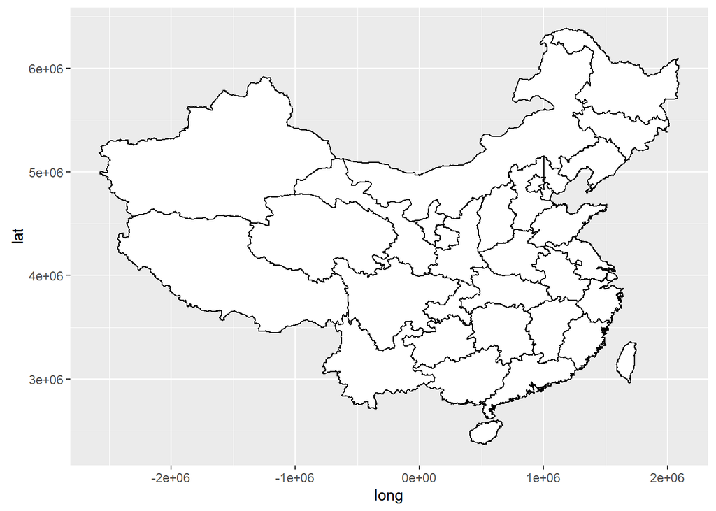

```r
#使用多边形绘图函数geom_polygon()绘制空的地图
ggplot(data = latitude_longitude, mapping = aes(x = long, y = lat,  group = id)) + geom_polygon(colour = 'black', fill = 'white')
```

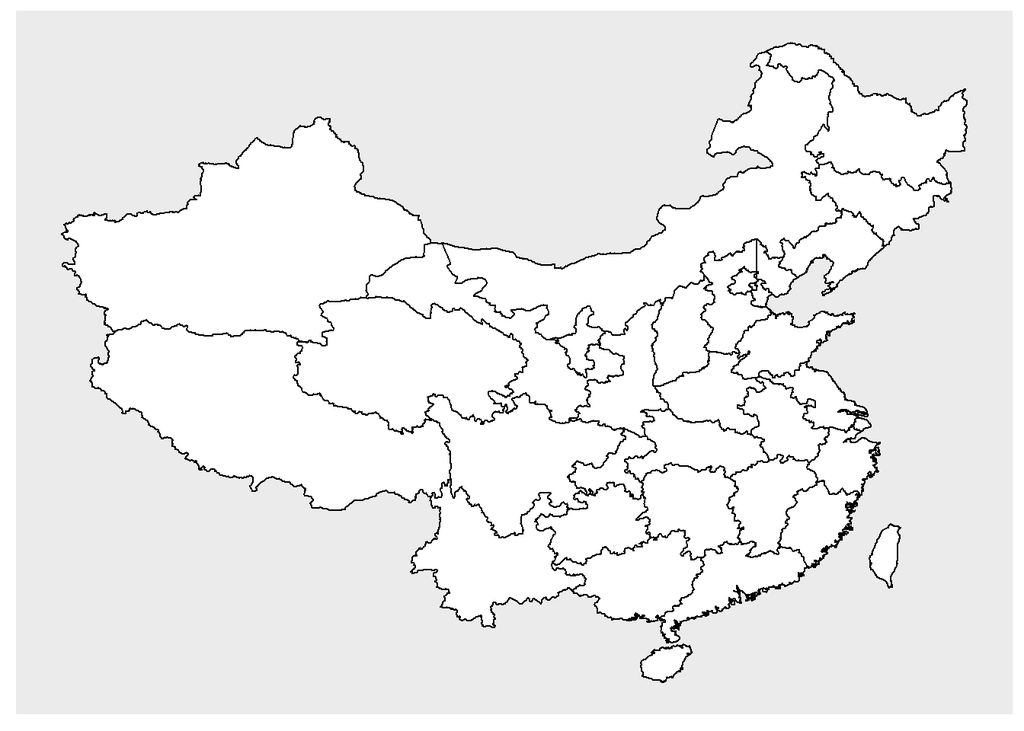

```r
#总觉得图中坐标轴的存在很别扭，该如何清除这些不必要的东西呢？

#清除不必要的附件(轴标签、刻度标签、刻度标记和网格线)
ggplot(data = latitude_longitude, mapping = aes(x = long, y = lat,  group = id)) + geom_polygon(colour = 'black', fill = 'white') + theme(axis.title = element_blank()) + theme(axis.text = element_blank()) + theme(axis.ticks = element_blank()) + theme(panel.grid = element_blank())
```

theme(axis.title = element_blank())用于清除图中的x轴和y轴标签 theme(axis.text = element_blank())用于清除图中x轴和y轴的刻度标签 theme(axis.ticks = element_blank())用于清除图中x轴和y轴的刻度标记 theme(panel.grid = element_blank())用于清除图中的网格线

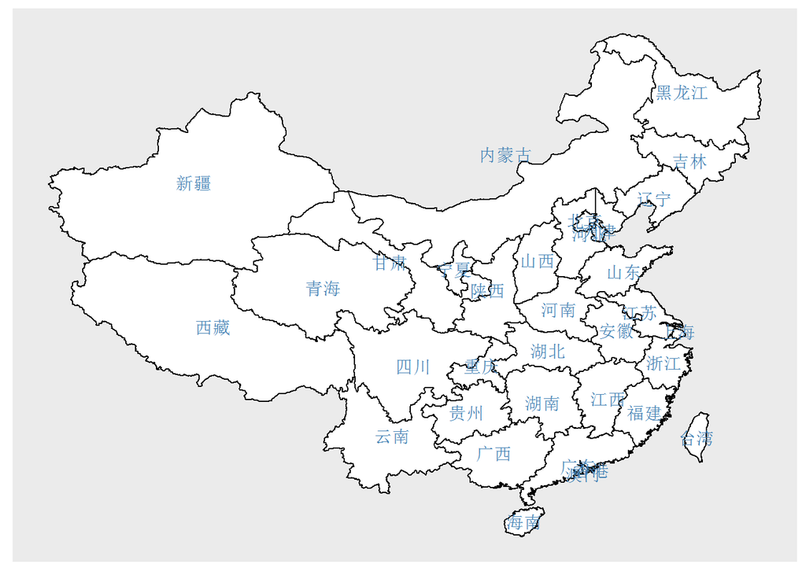

```r
#将各省份的名称显示在地图中，这里多个主题函数theme()可以将参数写到一起。
ggplot(data = latitude_longitude, mapping = aes(x = long, y = lat,  group = id)) + geom_polygon(colour = 'black', fill = 'white') + scale_fill_manual(values=colours(),guide=FALSE) + geom_text(mapping = aes(x = longitude, y = latitude, label = NAME), data = Province_Info, colour = 'steelblue') + theme(axis.title = element_blank(), axis.text = element_blank(), axis.ticks = element_blank(), panel.grid = element_blank())
```

不错，就是通过图层叠加的方法，将对于位置的省份名称贴在地图中。这里通过geom_text()函数实现，需要注意的是，geom_text()函数又使用了另一个数据框的数据内容。

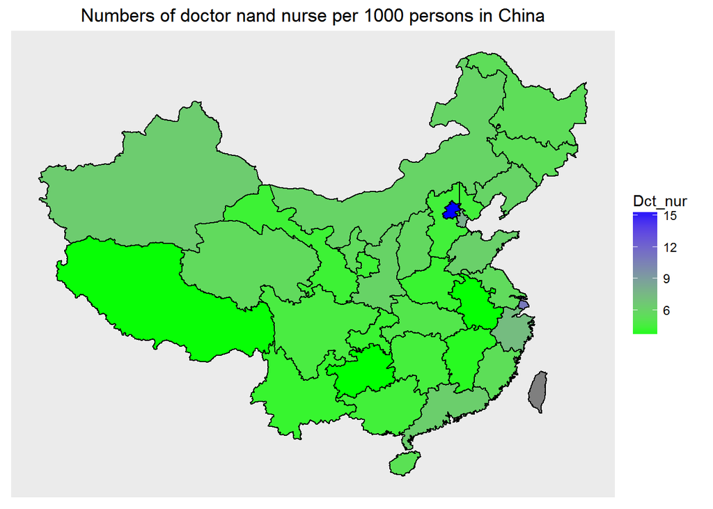

```r
#用颜色填充各个省份，颜色深浅表示“平均每千人医护人员数”的多少
ggplot(data = latitude_longitude, mapping = aes(x = long, y = lat,  group = id, fill = Dct_nur)) + geom_polygon(colour = 'black') + scale_fill_gradient(low = 'green', high = 'blue') + labs(title ="Numbers of doctor nand nurse per 1000 persons in China") +  theme(axis.title = element_blank(), axis.text = element_blank(), axis.ticks = element_blank(), panel.grid = element_blank())
```

发现图中，台湾地区的颜色为灰色，并不在对于的色阶中，是因为医疗数据中没有对应的台湾数据。其实香港和澳门也没响应的数据，这里并没法发现，是因为这两个地区面积太小而无法识别出。

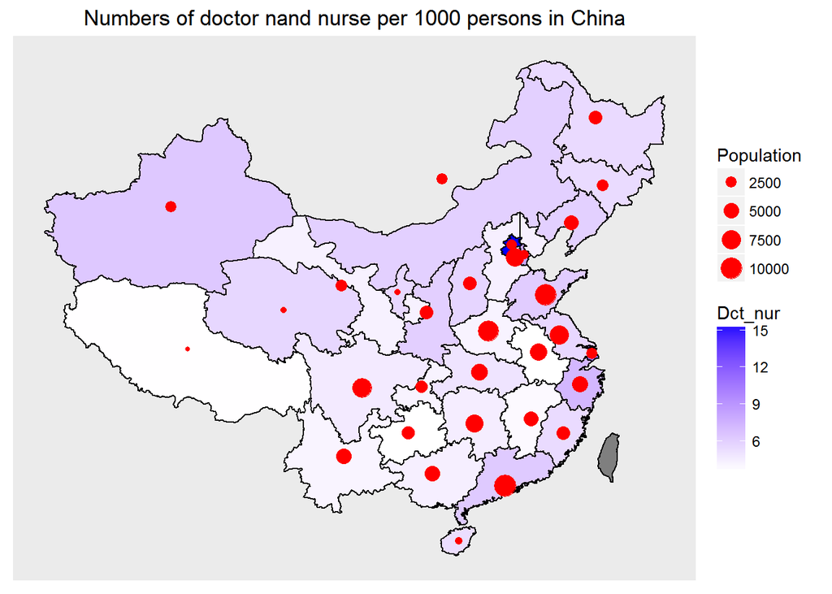

```r
#在上一幅图的基础上，在绘制气泡图，气泡大小表示人口数量
ggplot(data = latitude_longitude, mapping = aes(x = long, y = lat,  group = id, fill = Dct_nur)) + geom_polygon(colour = 'black') + geom_point(mapping = aes(x = longitude, y = latitude, size = Population), data = Province_Info, colour = 'red') + scale_fill_gradient(low = 'white', high = 'blue') + labs(title ="Numbers of doctor nand nurse per 1000 persons in China") + scale_size_area() + theme(axis.title = element_blank(), axis.text = element_blank(), axis.ticks = element_blank(), panel.grid = element_blank())
```

```r
#这里港澳台地区的人口数位置，故没有响应的气泡。
```

除了可以在地图里添加气泡图，还可以往地图里添加条形图，具体如下：

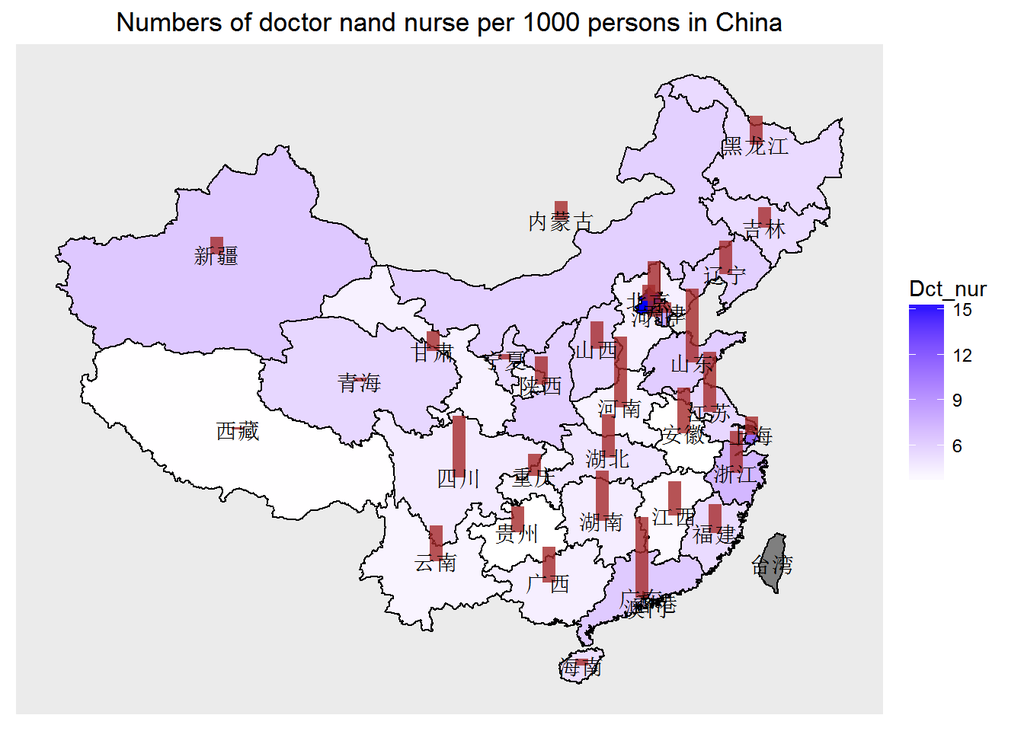

```r
ggplot() + geom_polygon(data = latitude_longitude, mapping = aes(x = long, y = lat,  group = id, fill = Dct_nur), colour = 'black') + geom_errorbar(mapping = aes(x = longitude, ymin = latitude, ymax =latitude + Population*50), data = Province_Info, colour = 'brown', size = 3, width = 1, alpha = 0.8) + geom_text(mapping = aes(x = longitude, y = latitude, label = NAME), data = Province_Info, colour = 'black') + scale_fill_gradient(low = 'white', high = 'blue') + labs(title ="Numbers of doctor nand nurse per 1000 persons in China") + scale_size_area() + theme(axis.title = element_blank(), axis.text = element_blank(), axis.ticks = element_blank(), panel.grid = element_blank())
```

```r
#需要提醒的是，ggplot()函数里不能传任何参数，地图只能在geom_polygon()函数中绘制，否则又将报错。
```

由于省份中心位置不是很准确，导致有些省名称、气泡和条形图没有落在准确的位置，后期将对省份中心位置的经纬度做进一步调整。

参考资料： http://bbs.pinggu.org/thread-4182165-1-1.html